# sparkTable: Generating Graphical Tables for Websites and Documents with R

Alexander Kowarik

Statistics Austria

Bernhard Meindl

Statistics Austria

Matthias Templ

CSTAT - Computational Statistics, Institute of Statistics & Mathematical Methods in Economics

2015-05-29

Abstract

Visual analysis of data is important to understand the main characteristics, main trends and relationships in data sets and it can be used to assess the data quality. Using the R package *sparkTable*, statistical tables holding quantitative information can be enhanced by including spark-type graphs such as sparklines and sparkbars .  
These kind of graphics are well-known in literature and are considered as simple, intense and illustrative graphs that are small enough to fit in a single line. Thus, they can easily enrich tables and texts with additional information in a comprehensive visual way.  
The R package *sparkTable* uses a clean S4 class design and provides methods to create different types of sparkgraphs that can be used in websites, presentations and documents. We also implemented an easy way for non-experts to create highly complex tables. In this case, graphical parameters can be interactively changed, variables can be sorted, graphs can be added and removed in an interactive manner. Thereby it is possible to produce custom-tailored graphical tables – standard tables that are enriched with graphs – that can be displayed in a browser and exported to various formats.

# Introduction

Without doubt, visualization of data becomes more and more important for data analysis and for presenting aggregated information for end-users and policy needs. For surveys on the history and developments in visualization we refer to (Friendly 2008) and (Wickham 2013). The reason for this is that the human eye is a very powerful pattern recognition tool. Readers can easily understand simple visual presentations of data like charts published every day in newspapers, the internet, television and scientific articles. The visual presentation of data should illustrate trends and relationships quickly and easily and should display key figures about data. For readers it is often much easier to understand statistics when seeing a chart or a map rather than being confronted with a long list of numbers (see, e.g., The United Nations Economic Commission for Europe 2009).

Cleveland and McGill (1987) state that information encoded in a graph depends on a number of aspects such as plotting symbols, length, slopes or colors. Changing any aspect of a graph possibly leads to a different perception and decoding of the information. Thus it is required to research aspects of graphical representation of data and finally come up with recommendations or best practices. This task has been been tackled by various authors (see, e.g., Cleveland and McGill 1987; Edward R. Tufte 1986). Cleveland and McGill (1987) suggest, for example, an optimum mid-angle of 45 degrees when comparing the slopes of different lines.[^1] Other suggestions on how to scale the data exist and are summarized in Heer and Agrawala (2006). Details on the choice of colors can be found in Zeileis, Hornik, and Murrell (2009).

#### Tables:

Tables are a comprehensive way to summarize the most important facts about complex data. The United Nations Economic Commission for Europe (2009) claims that a small, well-formatted table can provide a great deal of information that readers can quickly absorb, and it, as well as Miller (2004), provide guidelines on how to design tables. However, the possibility of including graphics in tables (and text) is not covered.

#### Tufte’s pioneer work:

In our contribution, several examples show how to improve tables by including small graphics in the tables. It is pointed out that an improved table can contain various visual elements. This was originally proposed by Edward R. Tufte (2001). He introduced the concept of sparklines and their application that is not limited to tables. These *intense, simple* and *word-sized graphics* sparklines can be embedded in continuous text and also match with other propositions he has made. For example, they can easily be used together with the small multiples approach (E. R. Tufte 1990). According to Tufte it is always important to answer the question *compared to what?* when looking at graphs. Thus, the concept of small multiples is simply to put multiple graphs next to each other to allow direct visual comparisons between different (graphical) objects. He also states that small multiples are the best design solution to present a wide range of problems.

Another proposition Tufte makes is to *show the data above all*. In order to do so he introduces the term of *data-ink ratio*. This ratio can be seen as the ink in a graph used to actually show data by the total ink used to print a graph. While the additional ink used for labels, axes, ticks and grids among others may help to improve graphs, it distracts attention from the most important part of the graph – the data values itself. Thus, in his view the data-ink ratio should be increased whenever possible and sparklines are a way to do so, since it is possible to show a high amount of data, trends and variations in small space. This concept has also been criticized. Inbar, Tractinsky, and Meyer (2007) evaluated people’s acceptance of the minimalist approach (by increasing the data-ink ratio) to visualize information; a standard bar-graph and a minimalist version (both in Edward R. Tufte 2001) were compared. The majority of evaluators was more attracted by the standard graph. However, they didn’t evaluate the case of placing sparklines in text or tables. Traditionally, the output in many areas of statistics is focused on tables (The United Nations Economic Commission for Europe 2009), this is especially true for official statistics. Large tables with lots of number provide a lot of information, but make it hard to grasp it. Visualization can provide tools to make effects in the data visible at first sight and can provide the possibility to show more of the data than by just showing the numbers.

#### Software to produce sparklines:

To make visualization methods applicable, software tools, which provide interactions with the data and provide reproducibility of any result, are needed.

To publish sparklines in newspapers has a long history. For example, the Huntsville Times reports the use of sparklines in their sports section on March 21, 2005. To produce this kind of sparklines and graphical tables, various software products are available. For example, SAS© and JMP© include such facilities.[^2] Also Microsoft Excel allows to produce sparklines and there are implementations to produce simple sparklines for Photoshop, Prism, DeltaMaster and matplotlib. Most of these solutions are closed-source and commercial.

# The *sparkTable* package

Our contribution goes a step beyond the before mentioned available tools. It is not just a re-implementation of sparklines in another software. Various improvements have been made and new features are available to the user.

The presented software is free and open-source, its features are designed in a well-specified, object-oriented manner with defined classes and methods. The presented software allows to save the sparklines in different output formats for easy inclusion in LaTeX or websites with many optional graphical features, i.e., the sparklines are highly customizable. The software features the simple generation of graphical tables with any statistical content that is automatically calculated from microdata. Finally, interactive features to create sparklines and sparktables are available and clickable in the browser.

In the following, a short introduction into the R package [*sparkTable*](https://CRAN.R-project.org/package=sparkTable) (Kowarik, Meindl, and Templ 2015) is given with the help of an example. The first version of the package was uploaded to the Comprehensive R Archive Network (CRAN) in May 2010 and has been improved various times since then.

The initial task was to find ways how common and frequent output such as tables and reports of statistical organizations could be improved using spark-type graphs and to find a technical solution to create these visualizations. Since R is gaining momentum in national statistical institutes all over the world, it was a natural choice to create an add-on package for R containing such functionality. There are a variety of reasons for this: one of them is the possibility to easily share and distribute the package and to instantly get feedback from users.

The goal was to create a free and open source software tool that allows the quick creation of spark-type graphics that could easily be included in various documents such as reports or web pages. Many examples for graphical tables have been produced and – based on the feedback from both colleagues and users – it seems as if graphical tables are an helpful tool to improve traditional, existing, tabular-based outputs of national statistical offices. Some of these graphical tables are presented below.

*sparkTable* can also be used by non experts in R. Interactive clickable features have been added to the package. Especially for graphical tables, some steps of abstraction are still required. However, it has been made easier to customize and change graphical tables by using interactive web applications. Instead of a formal description of classes and methods and internal implementation of the package, the functionality of the package is illustrated with examples.

# Command line usage of *sparkTable* by example

The first step is to install and load the package. We assume that R has already been started. Then the package can be simply installed from any CRAN server.

Help files can be accessed from R by typing `help(package = "sparkTable")` into the console. This results in a browse-able, linked help archive. Each method, function and data set that comes with the package is documented and also some example code is provided which allows users to become familiar with the package. So as to demonstrate the facilities of *sparkTable*, example data sets available in the package are used.

Table 1 shows the most important functions and classes of the *sparkTable* package. Basic functions are available to produce sparklines, e.g., `newSparkLine` to create an object of class ‘`sparkline`’ that can be used as input for the plotting method `plot()` which dispatches based on the class of the input method. Using method `export()` it is possible to save mini-plots as files (pdf, png or eps) on the hard-disk. In addition, functions are available to produce graphical tables and calculate summary statistics for tables, see 3.1 and 3.2 for practical examples and more explanations.

Table 1: Most important functions of package *sparkTable*.

| **Function** | **Description** | **Comment** |
| --- | --- | --- |
| `newSparkLine()` `newSparkBar()` `newSparkBox()` `newSparkHist()` | creation of sparklines, sparkbars, sparkboxplots and sparkhistograms that may serve as the base for creating graphical tables | creates objects of class ‘`sparkline`’, ‘`sparkbar`’, ‘`sparkbox`’ and ‘`sparkhist`’ |
| `plot()` | plots objects of class ‘`sparkline`’, ‘`sparkbar`’, ‘`sparkhist`’ or ‘`sparkbox`’ |  |
| `export()` | saves objects of class ‘`sparkline`’, ‘`sparkbar`’, ‘`sparkhist`’, ‘`sparkbox`’ or ‘`sparkTable`’ |  |
| `summaryST()` | summary for a data frame in a graphical table | creates an object of class ‘`sparkTable`’. Customize the output with `setParameter()` |
| `newSparkTable()` | function to create an object of class ‘`sparkTable`’ |  |
| `getParameter()`, `setParameter()` | basic functions to set parameters for objects of class ‘`sparkline`’, ‘`sparkbar`’, ‘`sparkbox`’, ‘`sparkTable`’ (or ‘`geoTable`’) |  |

In the following we show how to create basic spark graphics in 3.1. Then we demonstrate how to produce graphical tables that include some sparks in 3.2. We finish by introducing the new interactive ways that can be used to change, modify and adjust objects generated with package *sparkTable* in 4.

## Basic sparks

The data set `pop`, which is included in the package, is used. This data set contains the Austrian population size for different age groups from 1981 to 2009. We start by loading the data set into the current R session.

```r
> data(pop, package = "sparkTable")
```

This data set – available in long-format – contains three variables. The variable `time` describes the year, variable `variable` the different age groups and variable `value` the corresponding population numbers. Next, an object, which contains all the information required to plot a first sparkline, is generated. This can be achieved using function `newSparkLine()`. Calling the function and only setting argument `values` to use the population data of Austria stored in vector `popges` as shown in the code listing below, we obtain a new object `sline` (respectively `slineIQR`, where also the Inter-Quartile-Range (IQR) is visualized) with default settings for a sparkline plot.

```r
> pop_ges <- pop$value[pop$variable == "Insgesamt"]
> sline <- newSparkLine(values = pop_ges)
> slineIQR <- newSparkLine(values = pop_ges, showIQR = TRUE)
```

The resulting object `sline` is of class ‘`sparkline`’ and has the default parameter settings. Later it is shown how to change specific settings of the graph using the generic function `setParameter()`. Note that it is also possible to directly change parameters using `newSparkLine()` directly. The help-files that can be accessed using `?newSparkLine` give an overview on the parameters that can be set or changed.

After creating a sparkline object it is possible to create a plot using function `plot()` or saving the graphic by applying method `export()`. Using these methods it is possible to plot and export not only objects of class ‘`sparkline`’ but also objects of class ‘`sparkBar`’ (generated with `newSparkBar()`), ‘`sparkBox`’ (generated with `newSparkBox()`) and ‘`sparkHist`’ (generated with `newSparkHist()`). The function `export()` requires a ‘`spark*`’ object as input and allows to specify the desired output format. Currently, one of the following output formats can be selected by changing the function argument `outputType`:

- `"pdf"`: the spark-graphic is saved in pdf-format;
- `"eps"`: the graph is saved as an encapsulated postscript file;
- `"png"`: the graphic is written to disk as a portable network graph.

The function argument `outputType` is serialized so that it is possible to create the graphics in all possible formats in one step. By the help of argument `filename`, users can specify an output filename for the resulting graphic. The code listing below shows how to save the sparkline represented in obj `sline` as a pdf-graphic with filename `first-sl.pdf`.

```r
> export(object = sline, outputType = "pdf",
+   filename = file.path("figures", "first-sl"))
> export(object = slineIQR, outputType = "pdf",
+   filename = file.path("figures", "first-sl-IQR"))
```

This graph can now easily be included in the current text showing the development

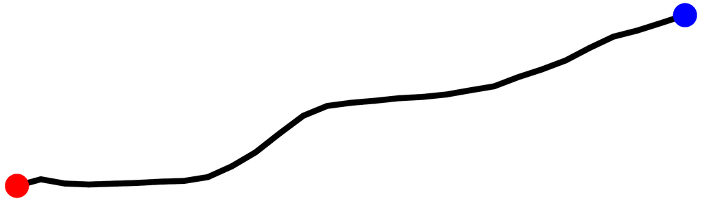

of the Austrian population from 1981 to 2009, alternatively with integrated IQR

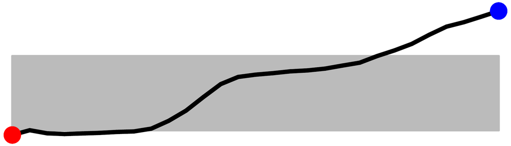

.

Similarly, other types of graphics can be produced. The next code listing highlights how to create other supported kind of word-graphs. In addition, some of the default parameters are changed.

```r
> v1 <- as.numeric(table(rpois(50, 2))); v2 <- rnorm(50)
> sbar <- newSparkBar(values = v1, barSpacingPerc = 5)
> sbox <- newSparkBox(values = v2, boxCol = c("black", "darkblue"))
> shist <- newSparkHist(values = v2, barCol = c("black", "darkgreen", "black"))
> export(object = sbar, outputType = "pdf",
+   filename = file.path("figures", "first-bar"))
> export(object = sbox, outputType = "pdf",
+   filename = file.path("figures", "first-box"))
> export(object = shist, outputType = "pdf",
+   filename = file.path("figures", "first-hist"))
```

Since they were exported as pdf-files, the produced

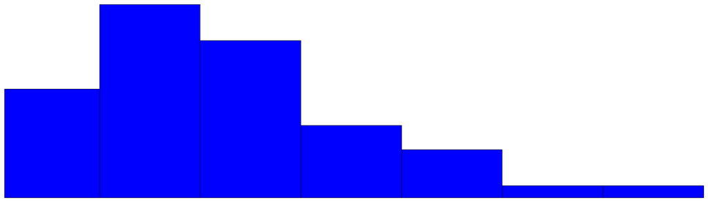

sparkbar, the

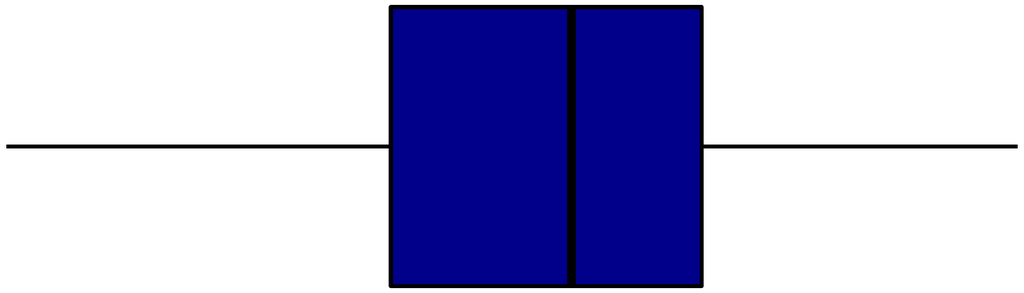

sparkbox and the

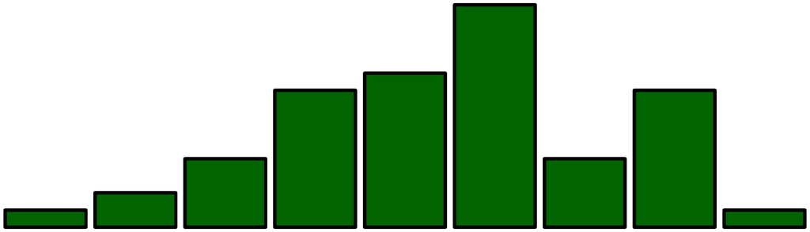

sparkhist can be easily integrated into a LaTeX-document as shown here.

We now show how to change some graphical parameters of the spark graphics we have just produced.

```r
> sline2 <- setParameter(sline, type = "lineWidth", value = 2)
> sline2 <- setParameter(sline2, type = "pointWidth", value = 5)
> export(object = sline2, outputType = "pdf",
+   filename = file.path("figures", "second-sl"))
```

For example the thickness of the line was changed in the sparkline object `sline2` from the default value of 1 to 2. Additionally, we changed the size of the points for special values in the sparkline to 5. If this line is plotted, the sparkline showing Austrian population numbers

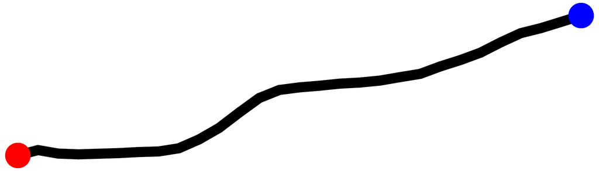

looks different.

It is worth noting that the current settings can be queried using function `getParameter()` in an analogue way as setting parameters by just leaving out the argument `values`. Detailed information about the kind of information that can be extracted using this function is available from the help page that is accessible via `?getParameter`.

Further, it is worth noting that these mini-graphs can also be directly included in fully automated reports. In the following example we show how to include a sparkline into a HTML-document that is created with [*knitr*](https://CRAN.R-project.org/package=knitr) (Xie 2014) and the *R markdown* language.

````r
```{r, echo=TRUE}
require(sparkTable)
sl <- newSparkLine(values = rnorm(25), lineWidth = .18, pointWidth = .4,
  width = .4, height = .08)
export(sl, outputType = "png", filename = "sparkLine")
```
This is a sparkline included in the ![firstSparkLine](sparkLine.png)
text...
````

Listing 1: Content of minimal markdown file that contains a sparkline.

A minimal example is shown in Listing 1. In the first part, a sparkline graph with random values is generated and saved as an image in png-format. We made sure that the height of the image equals approximately the height of a single line. Using markdown code, this image is finally included in the text. The integration in LaTeX , using `Sweave`, *knitr* or [*brew*](https://CRAN.R-project.org/package=brew) (Horner 2011), is straightforward, i.e., the code environment in Listing 1 needs to be changed to `Sweave`, *knitr* or *brew* style.

## Graphical tables

In 3.1, the basic usage of the package *sparkTable* to produce sparklines was demonstrated. Now we show how to enrich tables by including sparkgraphs. In addition, it is shown how spark-graphs can be used to visualize regional indicators in so-called checkerplots (Templ et al. 2013). We point out that existing tools – specifically [*xtable*](https://CRAN.R-project.org/package=xtable) (Dahl 2014) – are used to generate the final output.

In order to plot a graphical table, the first step is to create a suitable input object - in this case an object of class ‘`sparkTable`’. Objects of this kind hold the data itself in a suitable format. Further, such objects contain a list with information about the type of graphs or functions on the data values that should be shown in the resulting table. Moreover, a vector of variable names must be listed to specify for which variables in the data input graphs should be produced. These steps can be achieved using function `newSparkTable()`. To illustrate this procedure, we give an example using results from the 2013/2014 soccer season in Austria.

```r
> # load data (in long format)
> data(AT_Soccer, package = "sparkTable")
> # first three observations to see the structure of the data
> head(AT_Soccer, 3)
```

```r
   team time points wl goaldiff shotgoal getgoal
1 Rapid    1      1  0        0        2       2
2 Rapid    2      3  1        4        4       0
3 Rapid    3      3  1        2        4       2
```

```r
> # prepare content
> content <- list(
+     function(x) { sum(x) },
+     function(x) { round(sum(x), 2) },
+     function(x) { round(sum(x), 2) },
+     newSparkLine(lineWidth = 2, pointWidth = 6), newSparkBar()
+ )
> names(content) <- c("Points", "ShotGoal", "GetGoal", "GoalDiff", "WinLose")
>
> # set variables
> vars <- c("points", "shotgoal", "getgoal", "goaldiff", "wl")
>
> # create the sparkTable object
> stab <- newSparkTable(dataObj = AT_Soccer, tableContent = content, varType = vars)
```

The required code to create a ‘`sparkTable`’ object as shown above can be splitted into four sections. In the first line the input data set (in suitable long format for function `newSparkTable()`) is loaded.

The next step is to prepare a list specifying the content of each column of the required table. In this case the table is specified by five columns. In the first three columns very simple user-defined functions are used to aggregate three different variables. Note that the provided function can be arbitrarily complex.

For the last two columns of the table, sparklines and sparkbars are created. In this case we show that it is also possible to change parameters directly when creating such objects. We used this possibility to change the thickness of the line and the size of points for sparklines as it was already described in 3.1. It should also be noted that the names of this input list correspond to column names in the resulting final table, therefore we set the names of this list to the desired column headers. For example, the first column in the final table will have column name *Points*.

After the object `stab` has been established, the graphical table can be created. The required code is shown below:

```r
> export(stab, outputType = "tex", filename = file.path("figures", "first-stab"),
+   graphNames = file.path("figures", "first-stab"))
```

Table 2: A graphical table featuring data values and sparkgraphs applied to Austrian soccer data. For each game in the entire season, wins are maked blue, defeats in read and no bars are plotted for draws. In addition we present differences in goals throughout the season an well as overall points and goals for each team.

Points

ShotGoal

GetGoal

GoalDiff

WinLose

Rapid

$62$

$63$

$40$

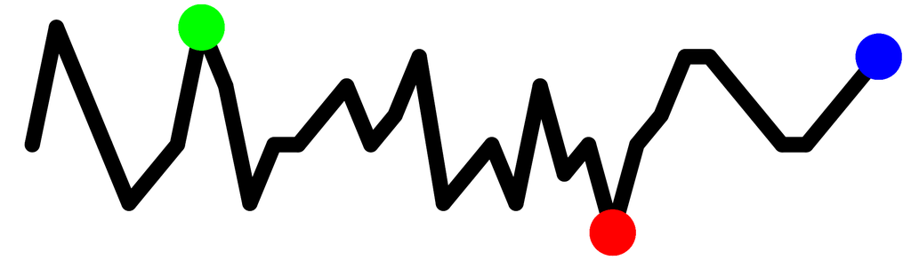

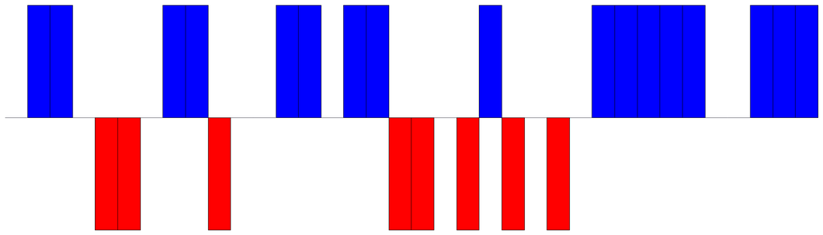

Salzburg

$80$

$110$

$35$

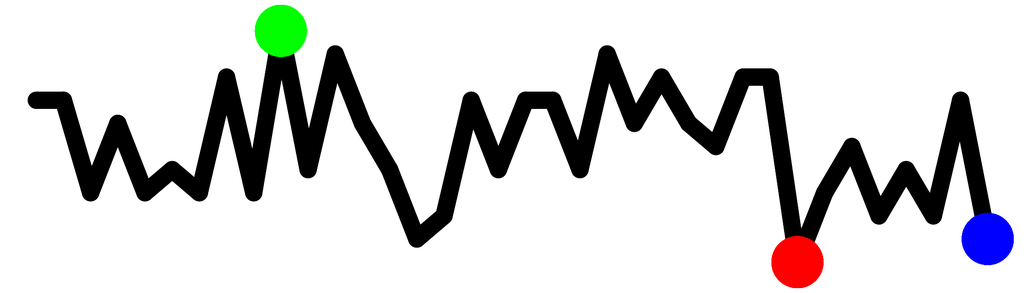

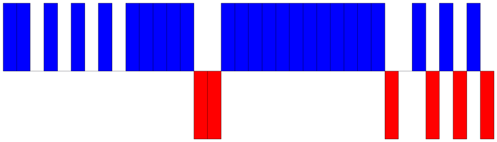

Austria

$53$

$58$

$44$

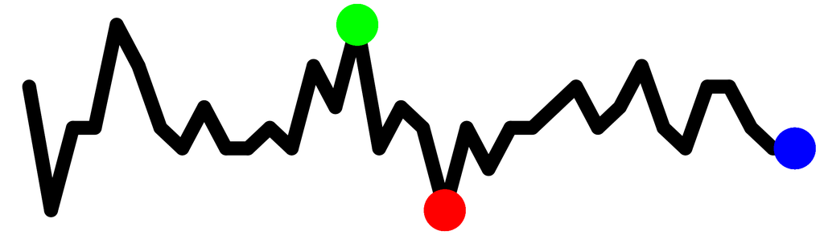

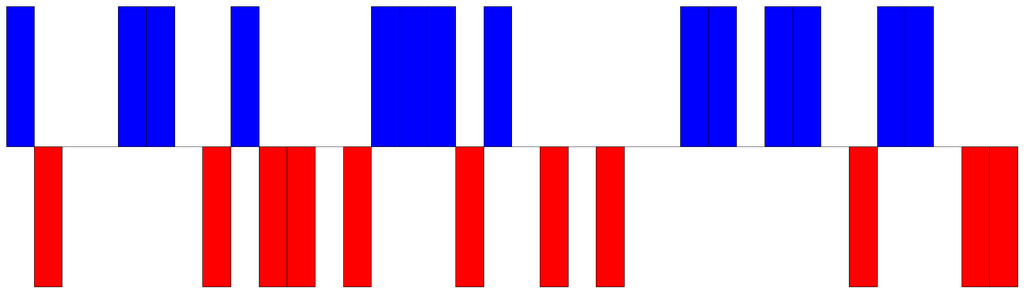

Sturm

$48$

$55$

$56$

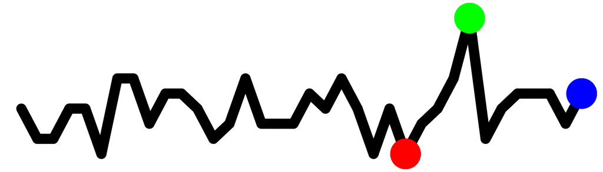

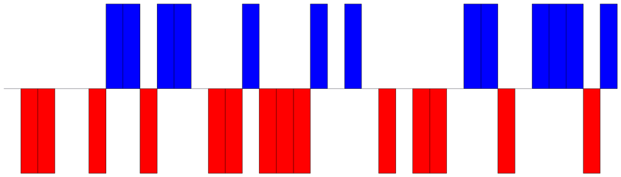

Groedig

$54$

$68$

$71$

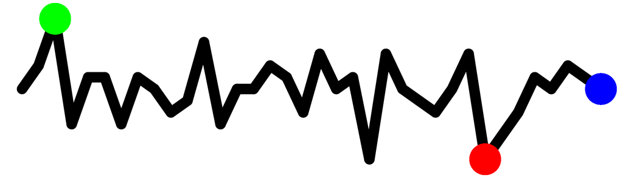

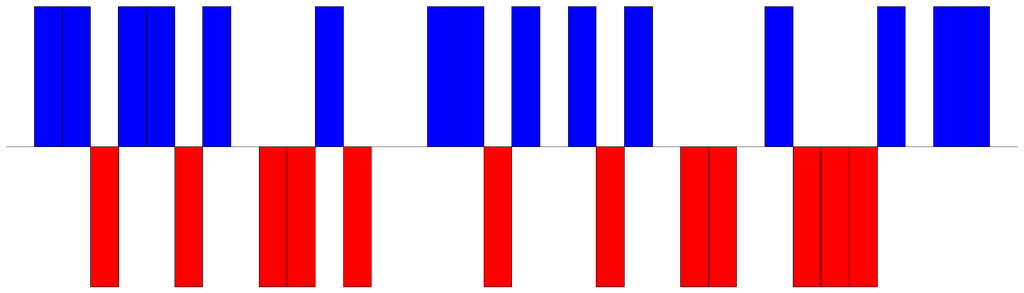

Neustadt

$39$

$43$

$84$

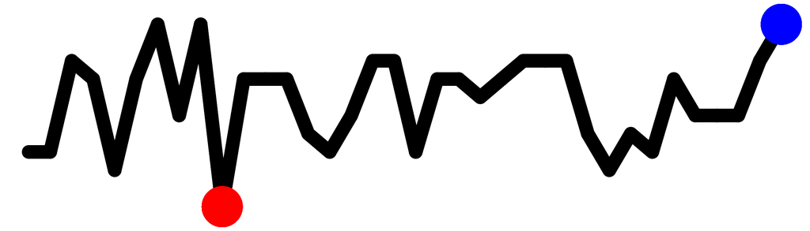

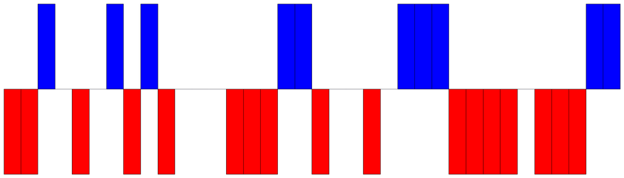

FC Wacker

$29$

$42$

$70$

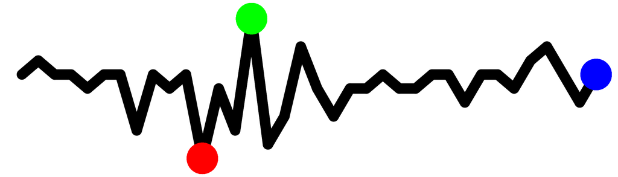

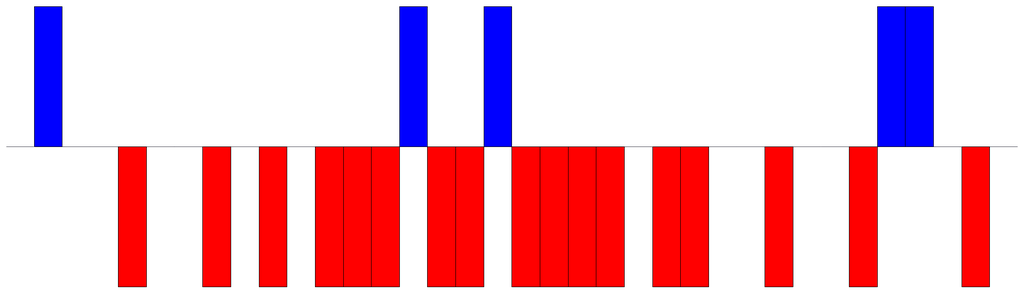

Wolfsberg

$41$

$51$

$63$

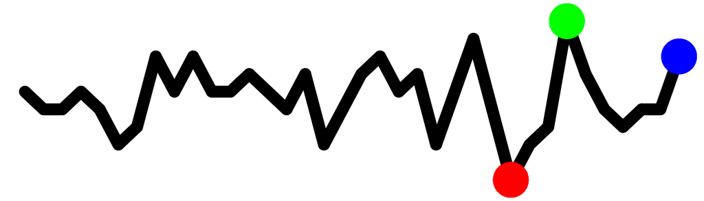

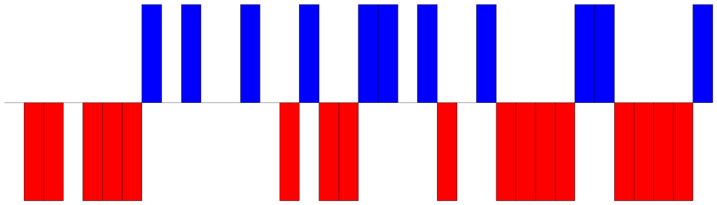

Ried

$43$

$55$

$66$

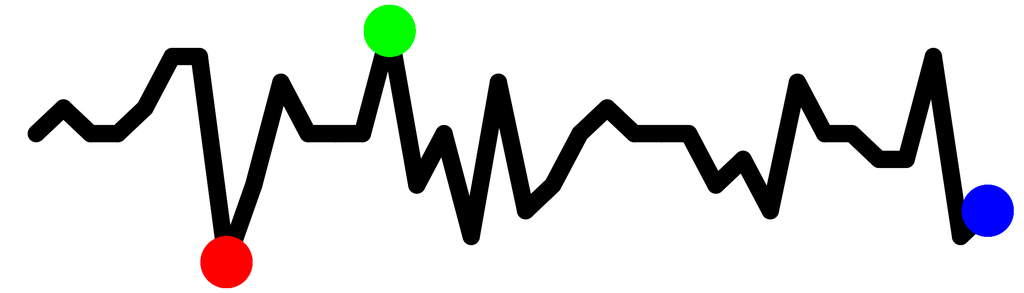

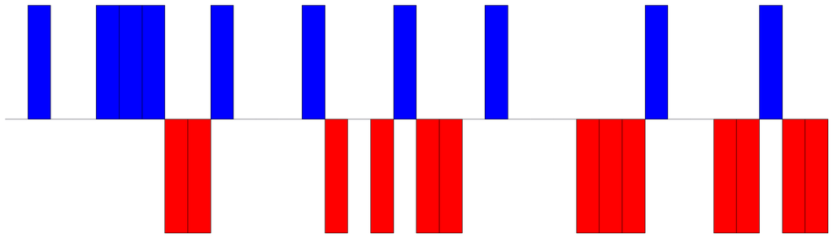

Admira

$42$

$51$

$67$

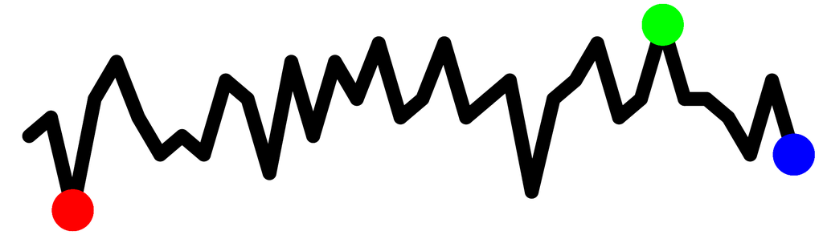

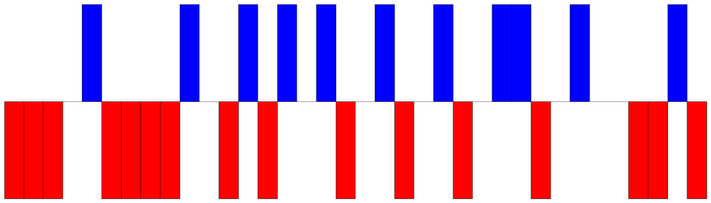

In case a user wants to include a table in LaTeX, a short tex-macro (*\graph*), which also has to be included in the LaTeX source, is printed by default in the R console. This information can be switched off by setting function argument `infonote` to `FALSE`.

## Geographical tables

The concept to create geographical tables is based on the concept of the so called checkerplot (Templ et al. 2013), which is also implemented in the package *sparkTable* in the function `checkerplot()`. We now show how to generate a geographical table for the EU using the function `newGeoTable()` and `plotGeoTable()`. The final result is shown in Table 3. Let us first load some data and print the first three rows of the data:

```r
> data(popEU, package = "sparkTable")
> data(debtEU, package = "sparkTable")
> data(coordsEU, package = "sparkTable")
> popEU <- popEU[popEU$country %in% coordsEU$country, ]
> debtEU <- debtEU[debtEU$country %in% coordsEU$country, ]
> EU <- cbind(popEU, debtEU[, -1])
> head(EU, 3)
```

```r
  country    B1999    B2000    B2001    B2002    B2003    B2004    B2005
1      BE 10213752 10239085 10263414 10309725 10355844 10396421 10445852
2      BG  8230371  8190876  8149468  7891095  7845841  7801273  7761049
3      CZ 10289621 10278098 10266546 10206436 10203269 10211455 10220577
     B2006    B2007    B2008    B2009    B2010 X1999 X2000 X2001 X2002
1 10511382 10584534 10666866 10753080 10839905 113.7 107.9 106.6 103.5
2  7718750  7679290  7640238  7606551  7563710  77.6  72.5  66.0  52.4
3 10251079 10287189 10381130 10467542 10506813  16.4  18.5  24.9  28.2
  X2003 X2004 X2005 X2006 X2007 X2008 X2009 X2010
1  98.5  94.2  92.1  88.1  84.2  89.6  96.2  96.8
2  44.4  37.0  27.5  21.6  17.2  13.7  14.6  16.2
3  29.8  30.1  29.7  29.4  29.0  30.0  35.3  38.5
```

Before we generate sparklines, the data has to be transformed to long format. `reshapeExt()` can be used to bring the data to the form so that `newSparkTable()` or `newGeoTable()` can be applied. In `reshapeExt()`, parameter `idvar` defines variables in long format that identify multiple records from the same group/individual and `v.names` corresponds to names of variables in the long format that correspond to multiple variables in the wide format, see `?reshapeExt` for details. We show the first two list elements of the reordered data:

```r
> EUlong <- reshapeExt(EU, idvar = "country", v.names = c("pop", "debt"),
+   varying = list(2:13, 14:25), geographicVar = "country", timeValues = 1999:2010)
> head(EUlong, 2)
```

```r
$BE
      country time      pop  debt
BE.1       BE 1999 10213752 113.7
BE.2       BE 2000 10239085 107.9
BE.3       BE 2001 10263414 106.6
BE.4       BE 2002 10309725 103.5
BE.5       BE 2003 10355844  98.5
BE.6       BE 2004 10396421  94.2
BE.7       BE 2005 10445852  92.1
BE.8       BE 2006 10511382  88.1
BE.9       BE 2007 10584534  84.2
BE.10      BE 2008 10666866  89.6
BE.11      BE 2009 10753080  96.2
BE.12      BE 2010 10839905  96.8

$BG
      country time     pop debt
BG.1       BG 1999 8230371 77.6
BG.2       BG 2000 8190876 72.5
BG.3       BG 2001 8149468 66.0
BG.4       BG 2002 7891095 52.4
BG.5       BG 2003 7845841 44.4
BG.6       BG 2004 7801273 37.0
BG.7       BG 2005 7761049 27.5
BG.8       BG 2006 7718750 21.6
BG.9       BG 2007 7679290 17.2
BG.10      BG 2008 7640238 13.7
BG.11      BG 2009 7606551 14.6
BG.12      BG 2010 7563710 16.2
```

The data is now ready and we can produce the geographical table:

```r
> l <- newSparkLine(lineWidth = 3, pointWidth = 10)
> content <- list(function(x) { "Population:" }, l, function(x) {"Debt:" }, l)
> varType <- c(rep("pop", 2), rep("debt", 2))
> xGeoEU <- newGeoTable(EUlong, content, varType, geographicVar = "country",
+   geographicInfo = coordsEU)
> export(xGeoEU, outputType = "tex", graphNames = file.path("figures", "out1"),
+   filename =  file.path("figures", "testEUT"), transpose = TRUE)
```

For the geographical representation in a grid, geographical coordinates have to be provided. Internally, an allocation problem is solved by linear programming to find the nearest free grid cell from the provided coordinates under several constraints. For this task, we refer to Templ et al. (2013), resulting in, for example, Scandinavian countries placed in the north, south Mediterranean countries in the south, etc. Again, the sparklines in each grid can be modified by function `setParameter()`.

Table 3: A geographical table featuring sparkgraphs for all EU countries.

**IS**

**NO**

**SE**

**FI**

**EE**

$Pop:$

$Pop:$

$Pop:$

$Pop:$

$Pop:$

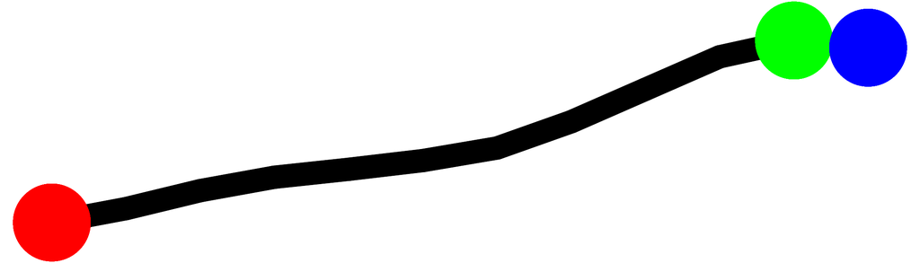

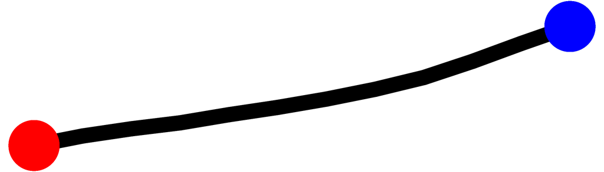

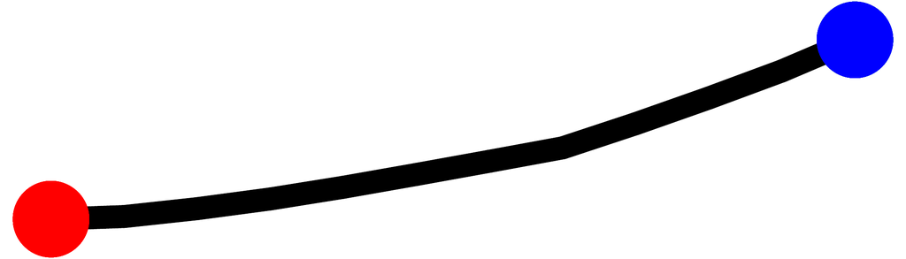

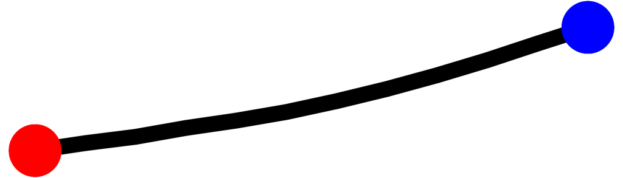

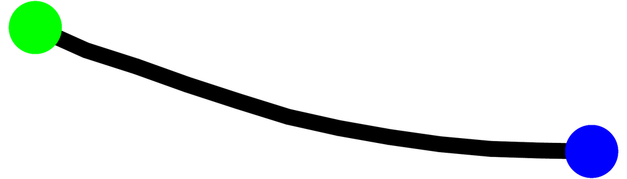

$Debt:$

$Debt:$

$Debt:$

$Debt:$